# Tutorial 6: Visualizations

DPI R Bootcamp

Jared Knowles

# Overview

In this lesson we hope to learn:

- What is data visualization and why does it matter?
- How to draw diagnostic plots in base graphics
- Colors
- `ggplot2'
- Basic geoms
- Layering and faceting plots
- Putting it together

# Graphics Matter

- Graphics are a huge part of R and R encourages its users to use visualization to aid and present analysis
- Graphics are hard to get right, but tools can help make it easier
- Lots of great resources to help available for this online and linked to at the end of this document

# Visualization Philosophy

- Visualization is about thinking about what objects in our dataset map with what visual cues for the viewer
- liberal use of `names(object)` helps
- What is the best way to show discrete variables, continuous variables, and connected variables
- We also need to be unafraid about trying transformations of variables, recoding variables, and reshaping variables to tell the story we are looking for
- What is a plot?

# Our data for this exercise

- As we now know, student data is quite fascinating
- We have many discrete attribute variables
- Race, gender, economics, etc.
- We have some continuous variables
- Test scores, attendance
- We have some grouping variables
- Schools, districts, students, teachers
- Rich ground to make a number of visualizations that are useful

# Base graphics

- R has base graphics which are useful for quickly doing some plots

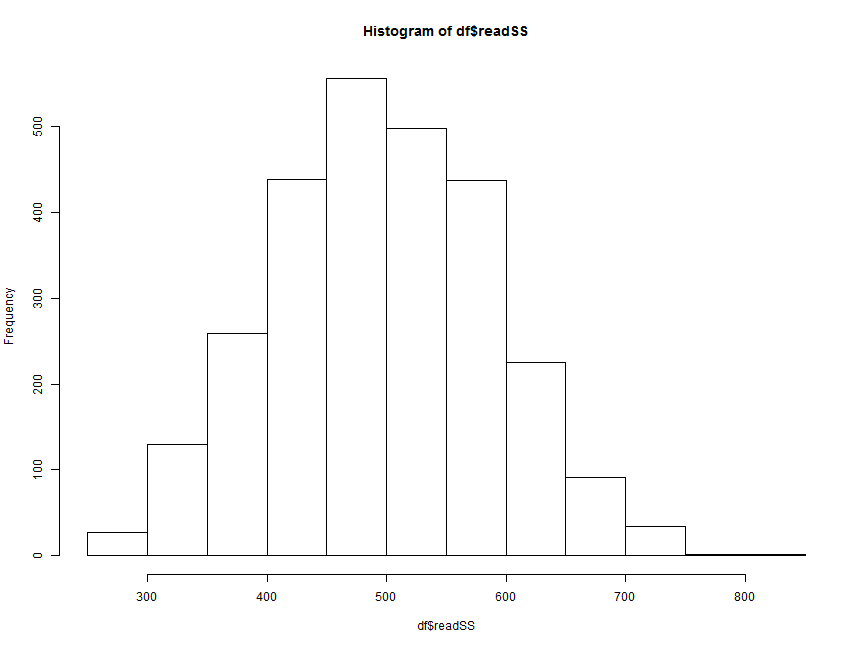

```r
hist(df$readSS)
```

# Base graphics are simple

- You can use them to understand your data and do quick diagnostics
- The commands are pretty easy to remember
- You can do complex things with them if you like, but the syntax can be confusing

# Base graphics has some limitations

- What if we try to do a scatterplot of lots of data?

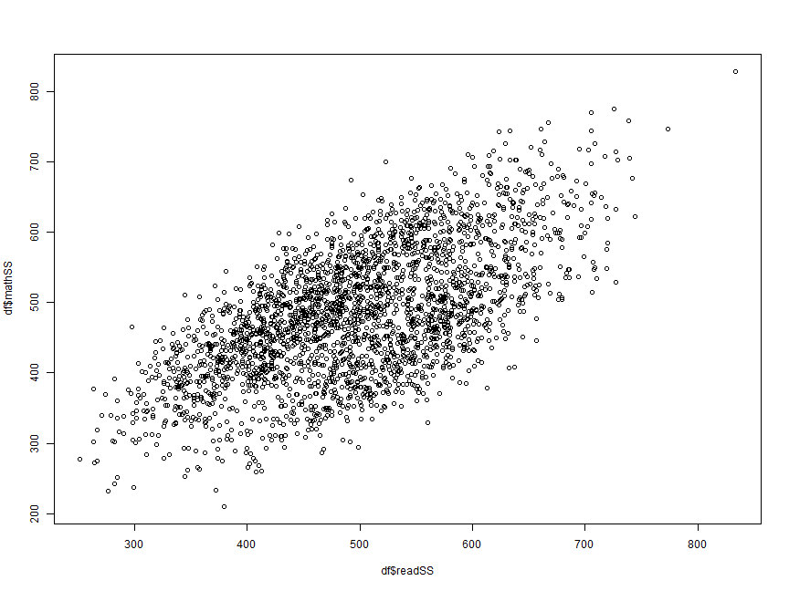

```r
plot(df$readSS, df$mathSS)
```

- To add a line, we have to use another line of code

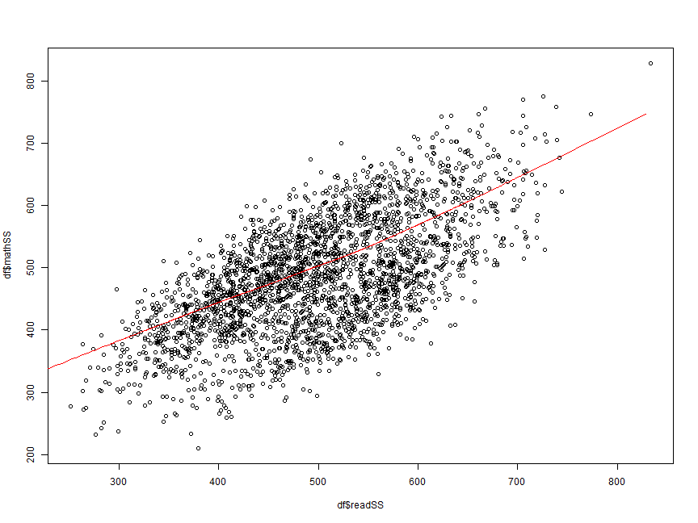

```r
plot(df$readSS, df$mathSS)
lines(lowess(df$readSS ~ df$mathSS), col = "red")
```

# Basic Plot

- Don't use R base graphics
- `ggplot2` is pretty much the new standard in R
- Create beautiful, clear plots with a nice consistent set of language conventions

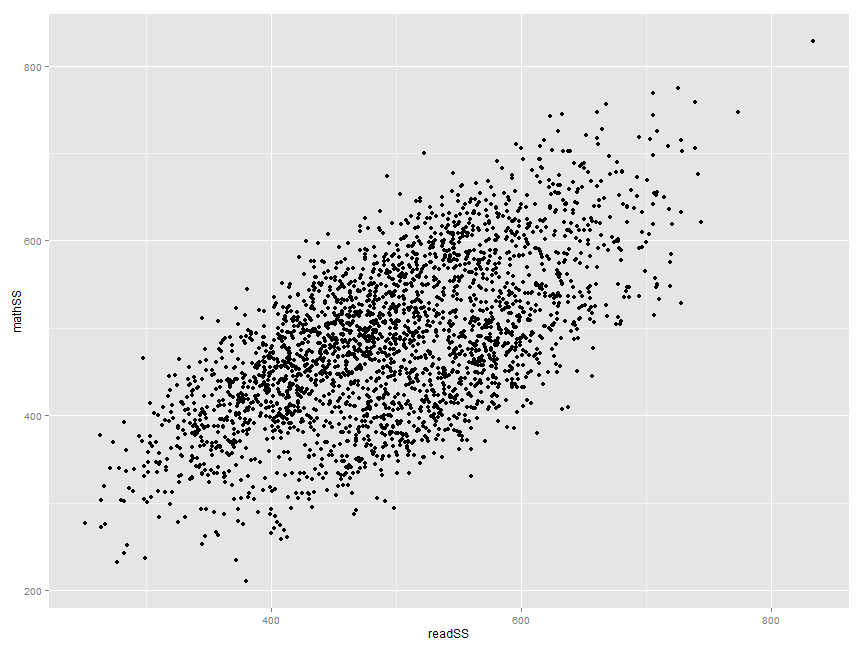

```r
library(ggplot2)
qplot(readSS, mathSS, data = df)
```

# Now, how?

- Apply best visualization principles, particularly the "Grammar of Graphics"
- `ggplot2` an R package does just this by breaking plots into a few basic components
- aesthetics, geoms, layers, and scales
- Making high quality graphics is just a matter of applying the right data to the right aesthetics in an appropriate geom, adding layer for detail, and ensuring the scale is appropriate
- Let's talk about how to do that next

# What are the basic plot types?

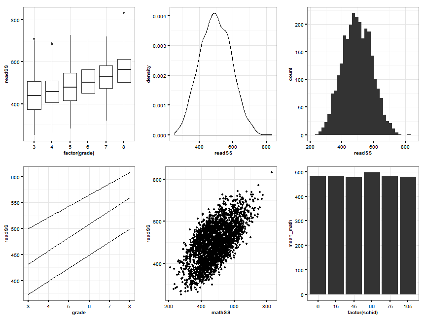

# What are some advanced plot types?

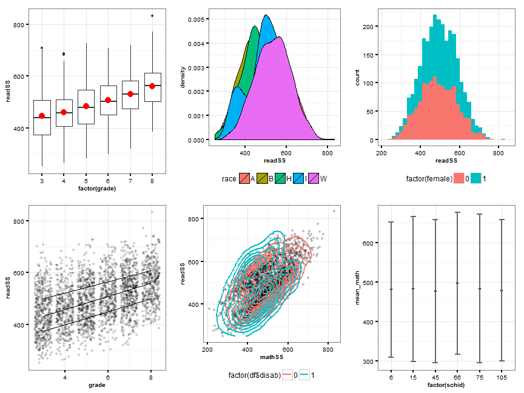

## Your Turn: What are some examples of interesting visualizations we could use?

# Understanding Grammar of Graphics through A Scatterplot

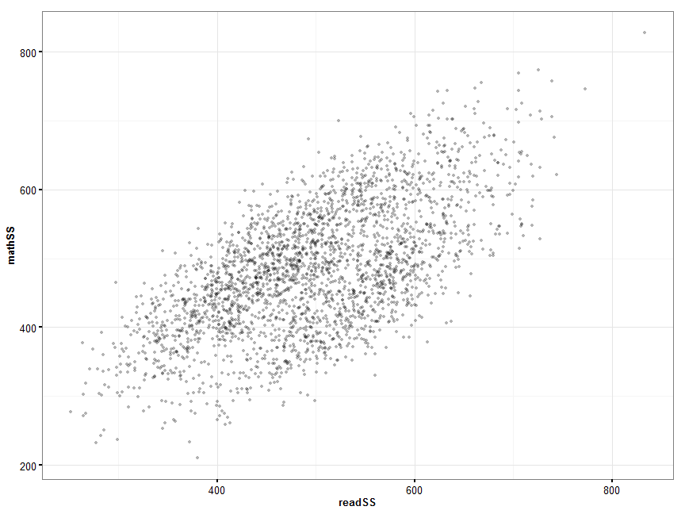

```r
qplot(readSS, mathSS, data = df, alpha = I(0.3)) + theme_dpi()
```

- What is a scatterplot?
- A 2d representation of data as coordinates, in this case the `readSS` is the x coordinate and `mathSS` is the y coordinate for each observation in our data
- Each observation is a point (*geom*)
- Both axes scale in a linear fashion (*scales*)

# Grammar of Graphics

- In one way of thinking about this, each data visualization has four components
- **Geometries** that represent data (*points, bars, lines*)
- **Statistics** that represent information about the data (*identity, mean, median, deviance*)
- **Scales** that map the geometries and statistics to space (*linear, quadratic, logrithmic*)
- A **coordinate system** and canvas to put all on

# Geoms

- **Geoms** are the way data is represented, you can think of it like a chart type in another programming language
- We have seen a number of examples, and **geoms** can be combined in unique ways to convey more data
- Quiz: Represent `df$mathSS` using **3 separate geoms**

# Geom Quiz

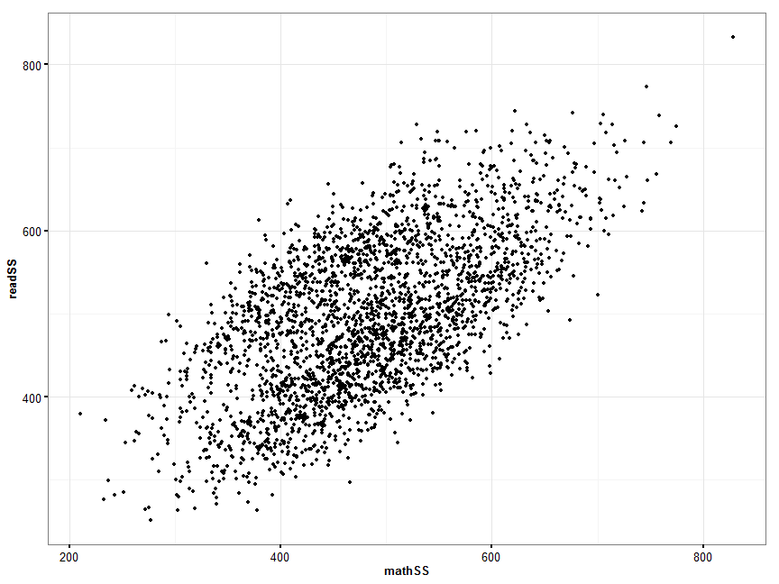

```r
qplot(mathSS, readSS, data = df) + theme_dpi()
```

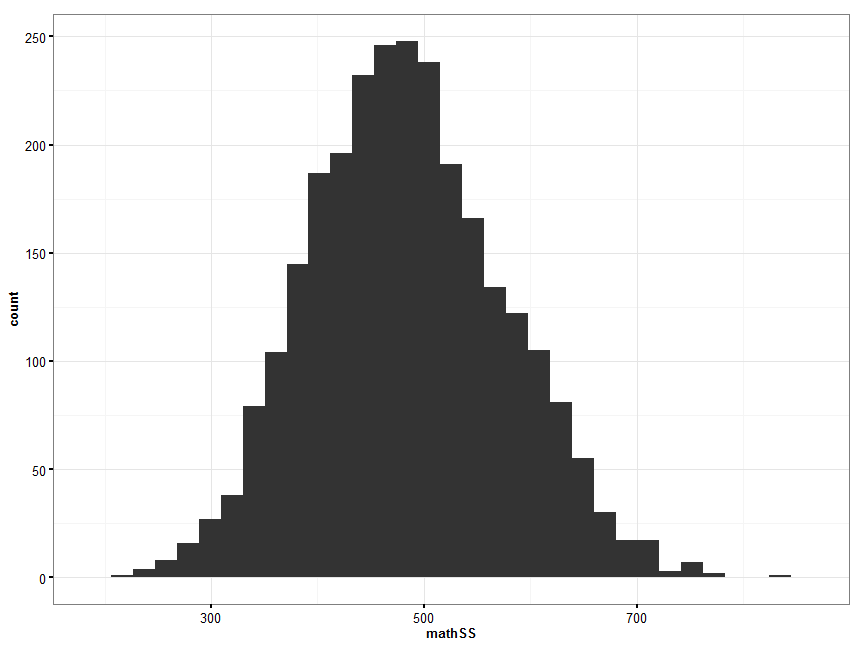

```r
qplot(mathSS, data = df) + theme_dpi()
```

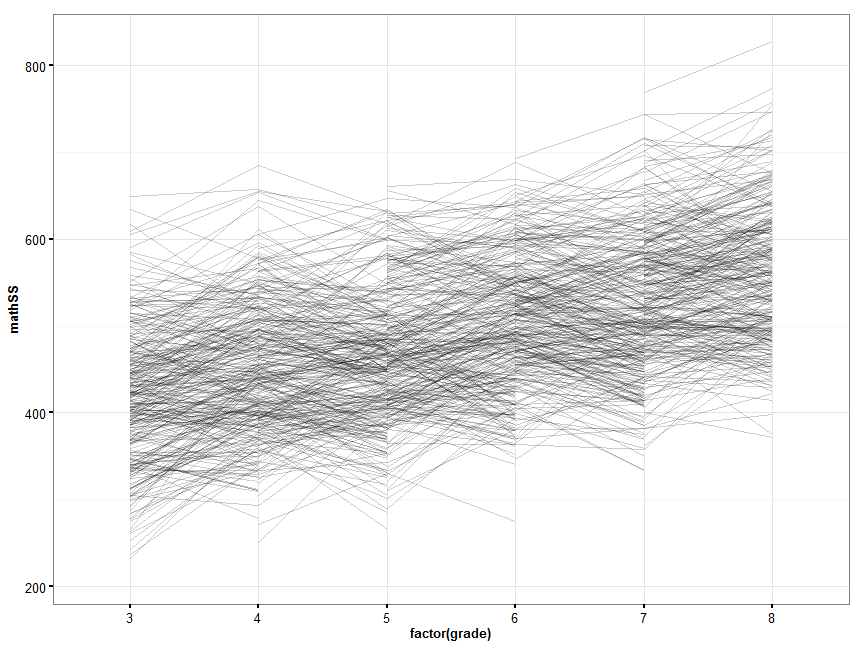

```r
qplot(factor(grade), mathSS, data = df, geom = "line", group = stuid, alpha = I(0.2)) +
    theme_dpi()
```

# Aesthetics

- **geoms** allow us to only display a couple of data elements at once, to do more we need to map to other visual representations
- This is what *aesthetics* are
- aesthetics are colors, glyphs (shapes), and sizes of graph objects mapped to visual cues
- `ggplot2` has an extended syntax that makes this obvious

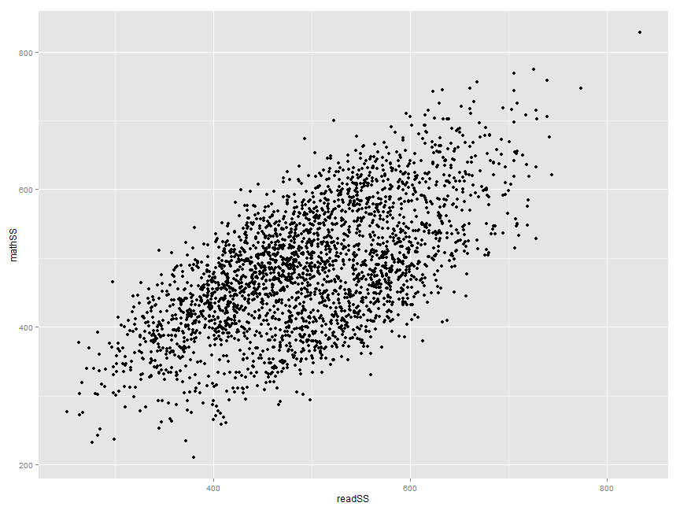

```r
ggplot(df, aes(x = readSS, y = mathSS)) + geom_point()
```

```r
# Identical to: qplot(readSS,mathSS,data=df)
```

- `aes` says we are specifying aesthetics, here we specified x and y to make a two dimensional graphic

# Examples of Aesthetics

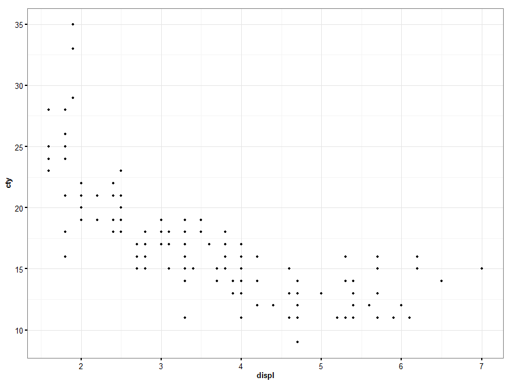

```r
data(mpg)
qplot(displ, cty, data = mpg) + theme_dpi()
```

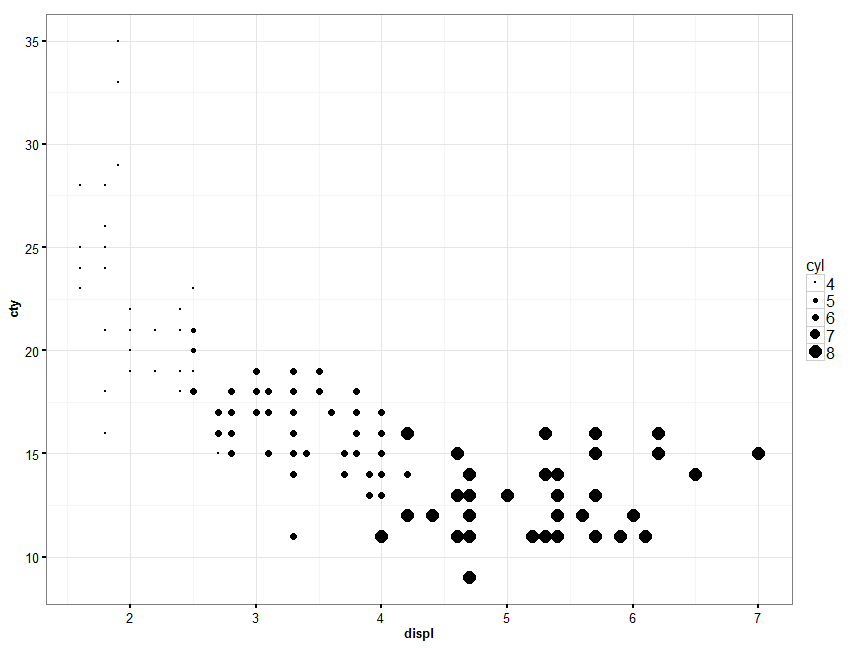

```r
qplot(displ, cty, data = mpg, size = cyl) + theme_dpi()
```

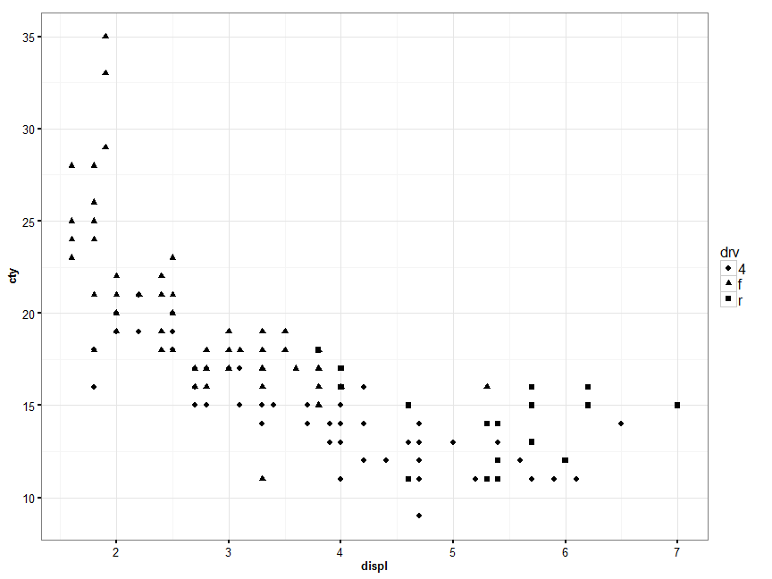

```r
qplot(displ, cty, data = mpg, shape = drv, size = I(3)) + theme_dpi()
```

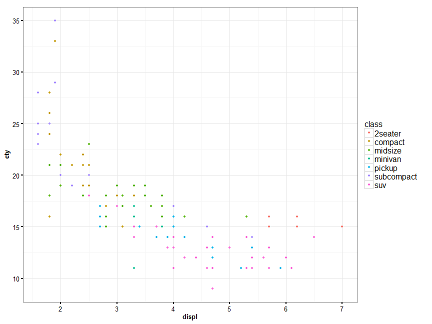

```r
qplot(displ, cty, data = mpg, color = class) + theme_dpi()
```

# Experiment with Aesthetics

### Draw some plots with different aesthetics using our student level dataset

# Some Considerations with Aesthetics

- **aesthetics** are very sensitive to whether a variable is continuous or discrete or ordered
- **R** isn't always so worried about this!
- Why does it matter? Let's see a few examples

# Aesthetics Considerations (ordered)

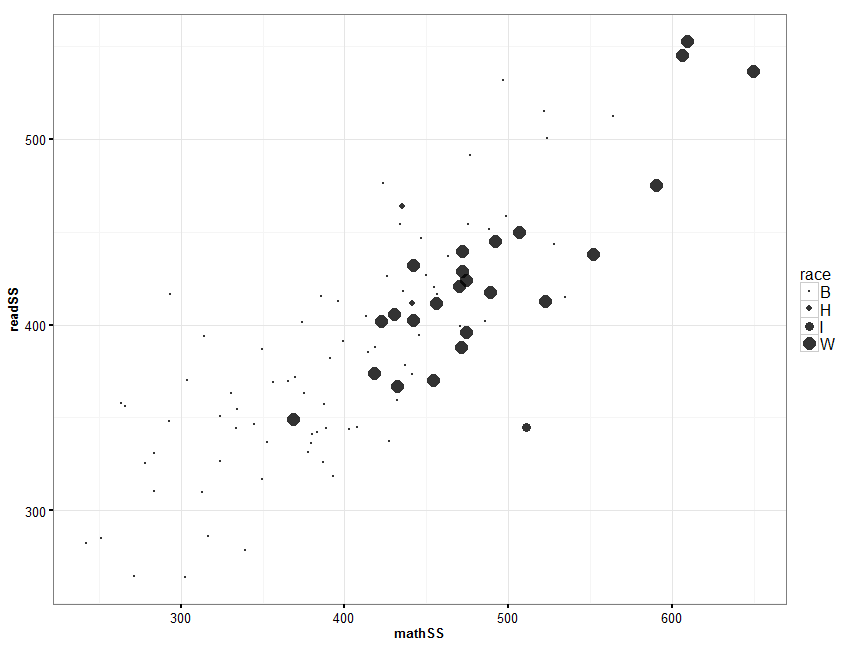

```r
qplot(mathSS, readSS, data = df[1:100, ], size = race, alpha = I(0.8)) + theme_dpi()
```

- Does this make sense?

# Another Aesthetics Concern (ordered)

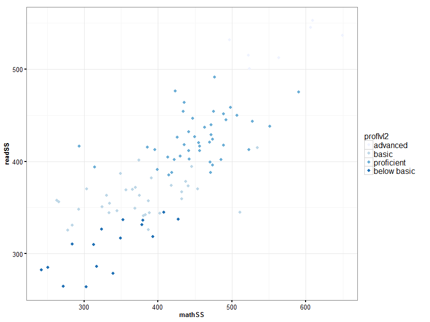

```r
df$proflvl2 <- factor(df$proflvl, levels = c("advanced", "basic", "proficient",
    "below basic"))
df$proflvl2 <- ordered(df$proflvl2)
qplot(mathSS, readSS, data = df[1:100, ], color = proflvl2, size = I(3)) + scale_color_brewer(type = "seq") +
    theme_dpi()
```

# Aesthetics Concern 2 (discrete and continuous)

- What aesthetics can we map continuous variables like `mathSS` to, and what can we map discrete characteristics like `race` to?

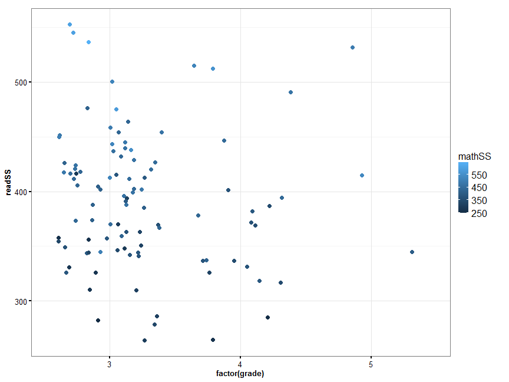

```r
qplot(factor(grade), readSS, data = df[1:100, ], color = mathSS, geom = "jitter",
    size = I(3.2)) + theme_dpi()
```

- What's wrong?

# Aesthetics Concern 2

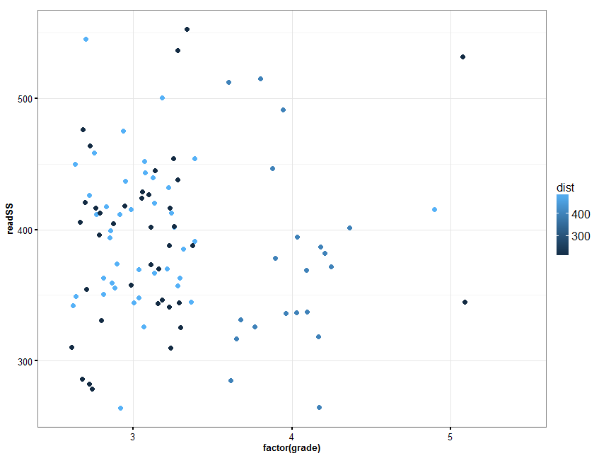

```r
qplot(factor(grade), readSS, data = df[1:100, ], color = dist, geom = "jitter",
    size = I(3.2)) + theme_dpi()
```

- What's wrong?

# Thinking about Aesthetics

- One concern is discrete v. continuous variables

| Aesthetic | Discrete | Continuous |
| --- | --- | --- |
| Color | Disparate colors | Sequential or divergent colors |
| Size | Unique size for each value | mapping to radius of value |
| Shape | A shape for each value | **does not make sense** |

# Another is ordered v. unordered

[output not shown]

# Scales

- Scales are the way the numeric/categorical data is mapped to a visual representation
- They transform the geoms and aesthetics
- Scales preserve the mapping, but allow us to explore reshaping the data

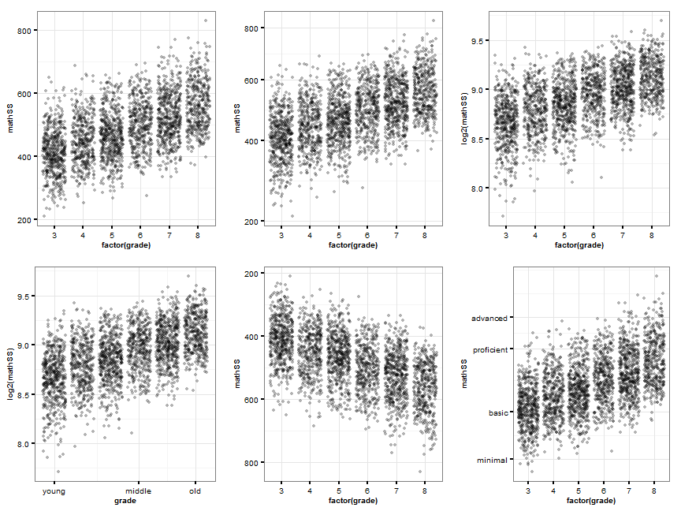

# Scales Caveats

- Despite not changing the mapping of data to space, scales can dramatically influence the interpretation of our data
- Rescaling data should be done thoughtfully and with care
- Picking a good scale can be really difficult, and sometimes, a good scale just won't exist without reshaping or subsetting the data!

# Scales also apply to color and fill

- The colors we choose can carry important meaning, as we have discussed
- So can the shapes we use for points, or for lines
- It is important to keep this in mind

# Layers

- Exactly what they sound like, each plot is a simple series of layers
- One way to do layers is to break plots up into small multiples (see Tufte)

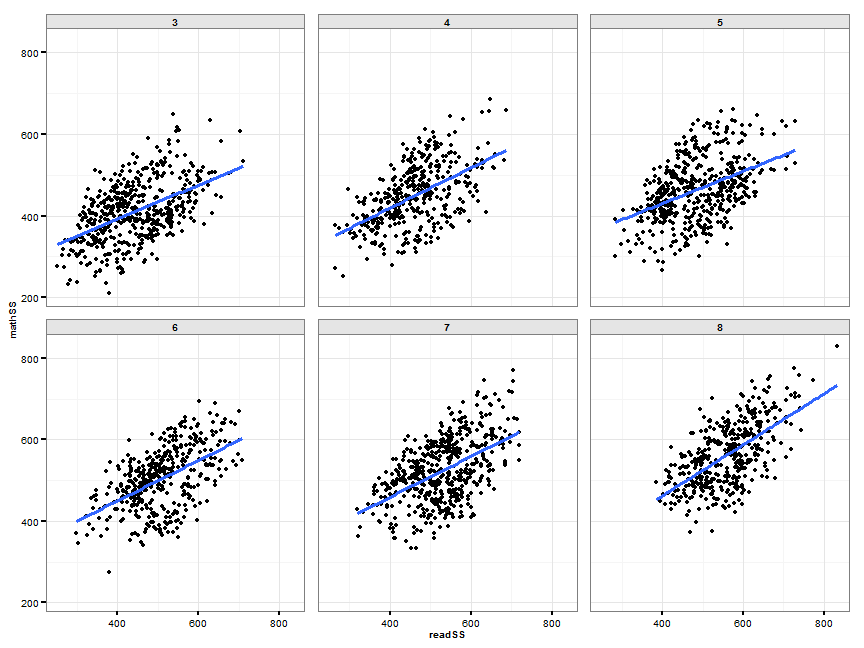

```r
qplot(readSS, mathSS, data = df) + facet_wrap(~grade) + theme_dpi(base_size = 12) +
    geom_smooth(method = "lm", se = FALSE, size = I(1.2))
```

# We can also facet across more attributes

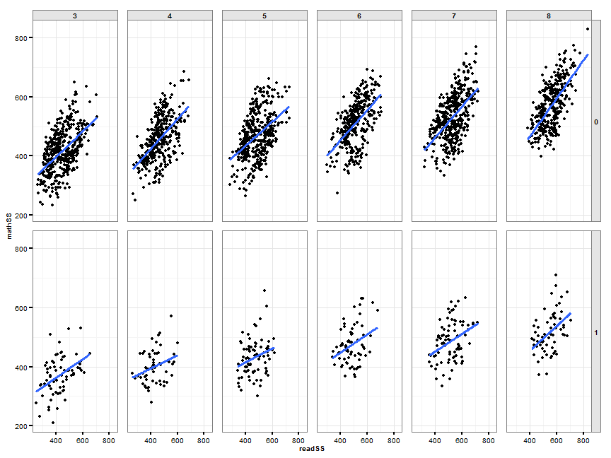

```r
qplot(readSS, mathSS, data = df) + facet_grid(ell ~ grade) + theme_dpi(base_size = 12) +
    geom_smooth(method = "lm", se = FALSE, size = I(1.2))
```

# Visualizing Categorical Data

- Visualization is not just limited to continuous data using scatterplots
- Sometimes we want to look at the density of data in different categories
- Sometimes we want to look at the size of groups compared to an expected group size
- What are some other examples?

# Structural Plots

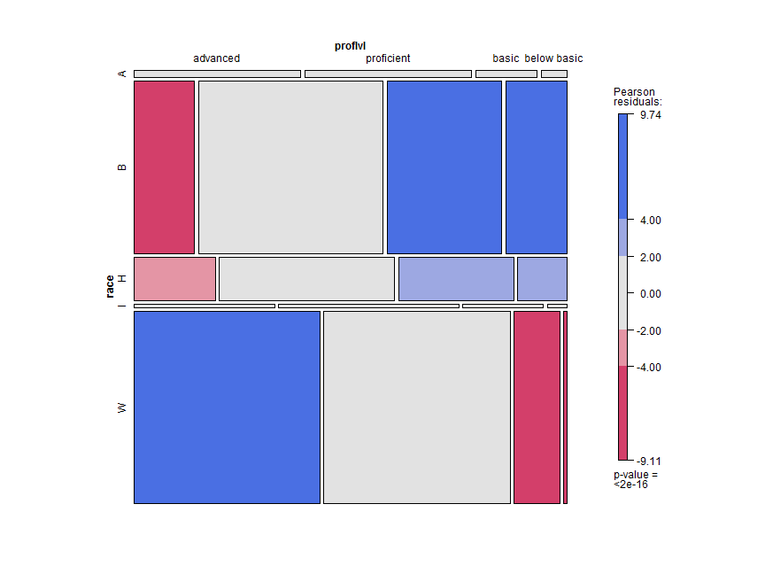

```r
library(vcd)
df$proflvl <- factor(df$proflvl, levels = c("advanced", "proficient", "basic",
    "below basic"))
a <- structable(proflvl ~ race, data = df)
mosaic(a, shade = TRUE)
```

# How do we interpret these plots?

- We use size and color to express proportionality and expected values
- This can be applied to other areas as well

# Another example

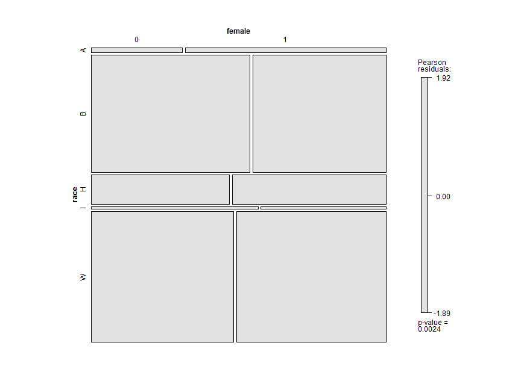

```r
library(vcd)
df$proflvl <- factor(df$proflvl, levels = c("advanced", "proficient", "basic",
    "below basic"))
a <- structable(female ~ race, data = df)
mosaic(a, shade = TRUE)
```

# A few pro tips

- Don't be afraid to manipulate the data
- Aggregate, combine, rescale variables to make the story easier to understand
- Don't use too much color
- People print your work, color blindness is more prevalent than you think
- Color is fickle. Monitors and projectors reproduce it differently.
- Don't overwhelm the user
- Make your visual depictions as easy as possible to immediately understand that data
- Don't plot everything all at once

# Colors in R

- ggplot2 default colors are based on maximizing space between colors using HCL
- Read more here: [A tutorial on ggplot2 colors](http://is-r.tumblr.com/post/34693674524/ggtutorial-day-3-introduction-to-colors); [HCL color](http://hclcolor.com)

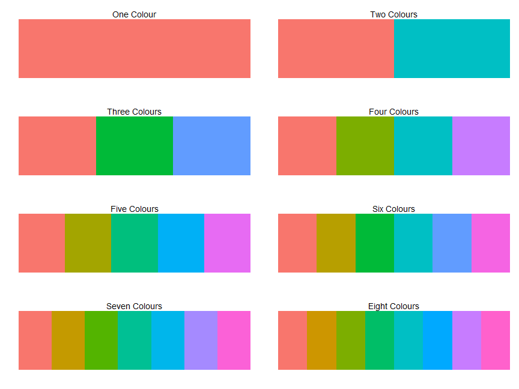

# The R Colorspace is Huge

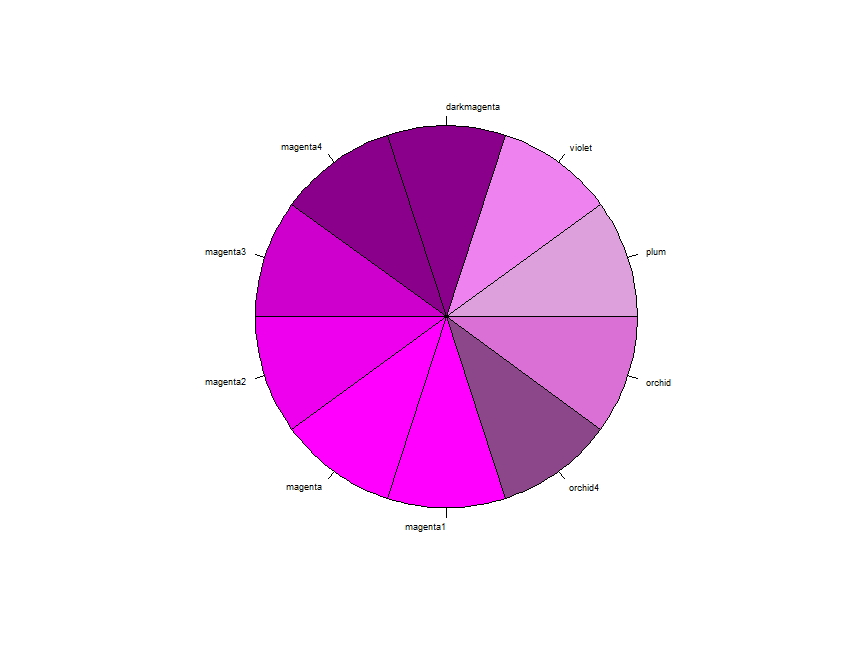

```
##  [1] "plum"        "violet"      "darkmagenta" "magenta4"    "magenta3"
##  [6] "magenta2"    "magenta"     "magenta1"    "orchid4"     "orchid"
```

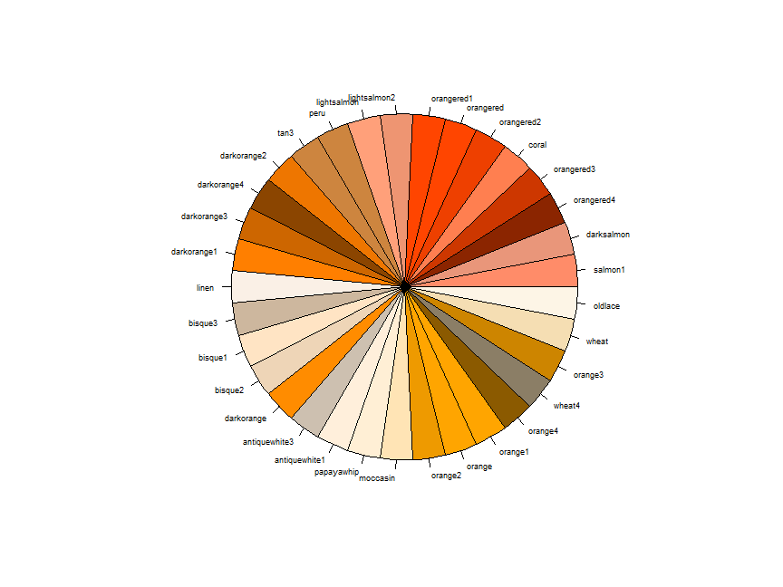

```
##  [1] "salmon1"       "darksalmon"    "orangered4"    "orangered3"
##  [5] "coral"         "orangered2"    "orangered"     "orangered1"
##  [9] "lightsalmon2"  "lightsalmon"   "peru"          "tan3"
## [13] "darkorange2"   "darkorange4"   "darkorange3"   "darkorange1"
## [17] "linen"         "bisque3"       "bisque1"       "bisque2"
## [21] "darkorange"    "antiquewhite3" "antiquewhite1" "papayawhip"
## [25] "moccasin"      "orange2"       "orange"        "orange1"
## [29] "orange4"       "wheat4"        "orange3"       "wheat"
## [33] "oldlace"
```

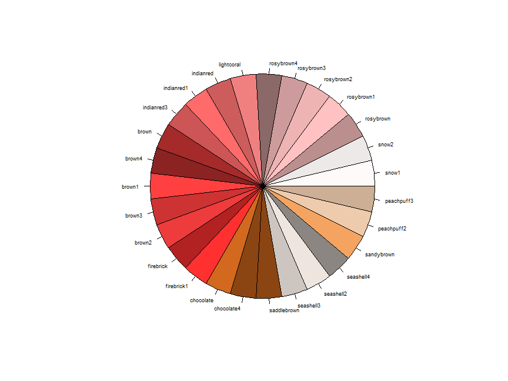

```
##  [1] "snow1"       "snow2"       "rosybrown"   "rosybrown1"  "rosybrown2"
##  [6] "rosybrown3"  "rosybrown4"  "lightcoral"  "indianred"   "indianred1"
## [11] "indianred3"  "brown"       "brown4"      "brown1"      "brown3"
## [16] "brown2"      "firebrick"   "firebrick1"  "chocolate"   "chocolate4"
## [21] "saddlebrown" "seashell3"   "seashell2"   "seashell4"   "sandybrown"
## [26] "peachpuff2"  "peachpuff3"
```

# Some Practical Advice

- Use [ColorBrewer palettes](http://colorbrewer2.org/): Available by default in ggplot2
- Designed for geographic mapping purposes to be easy to distinguish, easy to interpret across a diverse array of users, and sensitive to color-blindness
- As easy in ggplot2 as adding any color scale: `+scale_color_brewer(palette"X")`
- You can choose from sequential palettes, diverging palettes, qualitative palettes,and many more--depending on how many colors you need and what makes sense in your data
- Let's think about colors a little more together

# Above and Beyond

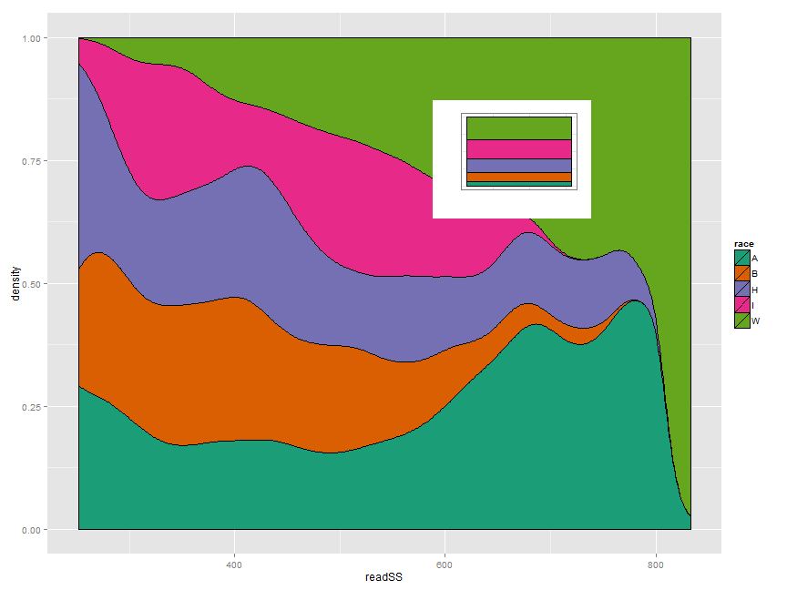

# Scary R Code

```r
library(grid)
p1<-qplot(readSS,..density..,data=df,fill=race,
      position='fill',geom='density')+scale_fill_brewer(
        type='qual',palette=2)

p2<-qplot(readSS,..fill..,data=df,fill=race,
      position='fill',geom='density')+scale_fill_brewer(
        type='qual',palette=2)+ylim(c(0,1))+theme_bw()+
          opts(legend.position='none',
               axis.text.x=theme_blank(),
               axis.text.y=theme_blank(),
               axis.ticks=theme_blank(),
               panel.margin=unit(0,"lines"))+ylab('')+
                 xlab('')

vp<-viewport(x=unit(.65,"npc"),y=unit(.73,"npc"),
             width=unit(.2,"npc"),height=unit(.2,"npc"))
print(p1)
print(p2,vp=vp)
```

# Exercises

1. Embed one plot in another plot in R using two different data elements from our data set. For example, plot a histogram of `readSS` inside a scatterplot of `readSS` and `mathSS`
2. Explore some examples on the ggplot2 website. What are some ways to overlay more than 3 dimensions of data in a single plot?
3. What types of data work best for what types of visualizations?

# References

1. [Hadley Wickham's JSM 2012 Presentation](http://www.stat.yale.edu/~jay/JSM2012/PDFs/ggplot2.pdf)
2. [Hadley Wickam's ggplot2 Intro Presentation](http://had.co.nz/ggplot2/resources/2007-vanderbilt.pdf)
3. [The ggplot2 Homepage](http://had.co.nz/ggplot2/)
4. [ggplot2 Documentation](http://had.co.nz/ggplot2/docs)
5. [Quick R: Basic Graphs](http://www.statmethods.net/graphs/index.html)
6. [Quick R: Advanced Graphs](http://www.statmethods.net/advgraphs/index.html)

# Session Info

It is good to include the session info, e.g. this document is produced with **knitr** version 0.9.6. Here is my session info:

[session information not shown]

# Attribution and License

This work (R Tutorial for Education, by Jared E. Knowles), in service of the [Wisconsin Department of Public Instruction](http://www.dpi.wi.gov), is free of known copyright restrictions.